# Week 10 Presentation

Yen-Ting Chen

2020/11/30

### Loading `iris`

Load `iris` and filter out all the other two species expect setosa.

```r
# Week 10 pres.
rm(list = ls())
data(iris) # measurement in centimeters
library(dplyr)
se <- iris %>% filter(Species == "setosa")
```

### Simple linear regression

Let’s say that I am interested in the relationship between sepal length and other factors.

I first run `lm` on setosa’s sepal length and width and see how it goes.

```r
# lm btw sepal length and width
model1<- lm(Sepal.Length~Sepal.Width, se) # checking the relationship betwenn sepal width and length
summary(model1)
```

```
##
## Call:
## lm(formula = Sepal.Length ~ Sepal.Width, data = se)
##
## Residuals:
##      Min       1Q   Median       3Q      Max
## -0.52476 -0.16286  0.02166  0.13833  0.44428
##
## Coefficients:
##             Estimate Std. Error t value Pr(>|t|)
## (Intercept)   2.6390     0.3100   8.513 3.74e-11 ***
## Sepal.Width   0.6905     0.0899   7.681 6.71e-10 ***
## ---
## Signif. codes:  0 '***' 0.001 '**' 0.01 '*' 0.05 '.' 0.1 ' ' 1
##
## Residual standard error: 0.2385 on 48 degrees of freedom
## Multiple R-squared:  0.5514, Adjusted R-squared:  0.542
## F-statistic: 58.99 on 1 and 48 DF,  p-value: 6.71e-10
```

Small p value from F statistics and strong significance of sepal width and the intercept. It is clear that there is a strong numerical relationship betweeen sepal length and width.

A graphical illustration

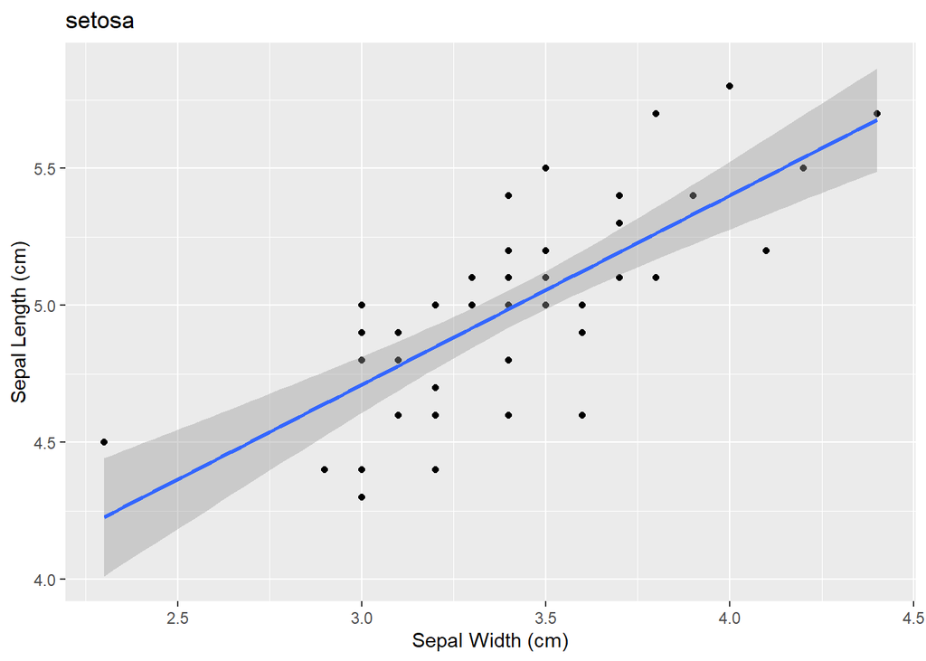

```r
# graphical illustration
library(ggplot2)
ggplot(se) + aes(x = Sepal.Width, y = Sepal.Length) + geom_point() + # structure of ggplot
  labs(title = "setosa", x = "Sepal Width (cm)", y = "Sepal Length (cm)") + # title, xlab, ylab
  stat_smooth(method = "lm", ) # reg line
```

### Multiple linear regression

Now I am curious about how other factors interact with sepal length in the species setosa (numerically of course!).

I run `lm` on all the other factors regarding setosa.

```r
# checking all the variables within setosa
model2 <- lm(Sepal.Length~., se[,1:4])
summary(model2)
```

```
##
## Call:
## lm(formula = Sepal.Length ~ ., data = se[, 1:4])
##
## Residuals:
##      Min       1Q   Median       3Q      Max
## -0.40662 -0.17721  0.01222  0.13388  0.49693
##
## Coefficients:
##              Estimate Std. Error t value Pr(>|t|)
## (Intercept)   2.35189    0.39287   5.986 3.03e-07 ***
## Sepal.Width   0.65483    0.09245   7.083 6.83e-09 ***
## Petal.Length  0.23756    0.20802   1.142    0.259
## Petal.Width   0.25213    0.34686   0.727    0.471
## ---
## Signif. codes:  0 '***' 0.001 '**' 0.01 '*' 0.05 '.' 0.1 ' ' 1
##
## Residual standard error: 0.2371 on 46 degrees of freedom
## Multiple R-squared:  0.5751, Adjusted R-squared:  0.5474
## F-statistic: 20.76 on 3 and 46 DF,  p-value: 1.192e-08
```

What we see right here is significance in r statistics, yet only sepal width and the associated intercept shows significance.

Checking the prediction power between model1 and model2.

```r
sigma(model1)/mean(iris$Sepal.Length)
```

```
## [1] 0.04082297
```

```r
sigma(model2)/mean(iris$Sepal.Length)
```

```
## [1] 0.04058159
```

### Model selection

Now considering finding/selecting the best model.

```r
MASS::stepAIC(model2)
```

```
## Start:  AIC=-140.08
## Sepal.Length ~ Sepal.Width + Petal.Length + Petal.Width
##
##                Df Sum of Sq    RSS     AIC
## - Petal.Width   1   0.02971 2.6164 -141.51
## - Petal.Length  1   0.07334 2.6600 -140.69
## <none>                      2.5866 -140.08
## - Sepal.Width   1   2.82133 5.4080 -105.21
##
## Step:  AIC=-141.51
## Sepal.Length ~ Sepal.Width + Petal.Length
##
##                Df Sum of Sq    RSS     AIC
## <none>                      2.6164 -141.51
## - Petal.Length  1   0.11496 2.7313 -141.36
## - Sepal.Width   1   3.03725 5.6536 -104.99
```

```
##
## Call:
## lm(formula = Sepal.Length ~ Sepal.Width + Petal.Length, data = se[,
##     1:4])
##
## Coefficients:
##  (Intercept)   Sepal.Width  Petal.Length
##       2.3037        0.6674        0.2834
```

```r
fore <- MASS::stepAIC(model2, direction = "forward")
```

```
## Start:  AIC=-140.08
## Sepal.Length ~ Sepal.Width + Petal.Length + Petal.Width
```

```r
back <- MASS::stepAIC(model2, direction = "backward")
```

```
## Start:  AIC=-140.08
## Sepal.Length ~ Sepal.Width + Petal.Length + Petal.Width
##
##                Df Sum of Sq    RSS     AIC
## - Petal.Width   1   0.02971 2.6164 -141.51
## - Petal.Length  1   0.07334 2.6600 -140.69
## <none>                      2.5866 -140.08
## - Sepal.Width   1   2.82133 5.4080 -105.21
##
## Step:  AIC=-141.51
## Sepal.Length ~ Sepal.Width + Petal.Length
##
##                Df Sum of Sq    RSS     AIC
## <none>                      2.6164 -141.51
## - Petal.Length  1   0.11496 2.7313 -141.36
## - Sepal.Width   1   3.03725 5.6536 -104.99
```